# lb3

**Мета:** *освоїти роботу зі змінними та операції вводу і виводу*

## Примітка

Перед виконанням лабораторної роботи необхідно опрацювати матеріал **Лекції 3**. :::

## Примітка

У лабораторній роботі використано матеріали [python institute.](https://pythoninstitute.org/pcep) :::

#### Що ви будете вміти?

- оперувати змінними строкового, цілого типу та типу з плаваючою комою.
- використовувати функцію `input()`.
- використовувати функції конвертації типів `int()`, `float()`, `string()`.

## Робота зі змінними

### Приклад

Написати програму, яка вводить довжини катетів $a$ та $b$ прямокутного трикутника та обчислює його гіпотенузу $c$.

```python
a = 3.0
b = 4.0
c = (a ** 2 + b ** 2) ** 0.5
print("c =", c)
```

```
c = 5.0
```

### Завдання № 1

Написати програму, яка обчислює значення функції Гауса: $$f(x) = \frac{1}{\sigma \sqrt{2 \pi}} e^{-\frac{(x-\mu)^2}{2\sigma^2}}$$

```python
# Тут має бути Ваш код
```

### Завдання № 2

Ось невелика розповідь:

Якось Джон (John) мав три яблука, Мері (Mary) мала п'ять яблук, а Адам (Adam) мав шість яблук. Усі вони були дуже щасливі та жили довго. Кінець історії.

Ваше завдання:

- створіть змінні: `john`, `mary`, і `adam`;
- надайте значення змінним. Значення повинні дорівнювати кількості фруктів, якими володіють Джон, Мері, і Адам відповідно;
- зберігши числа в змінних, виведіть змінні в один рядок і розділіть їх комами;
- тепер створіть нову змінну з ім'ям `totalApple`, що дорівнює сумі трьох попередніх змінних;
- вивести значення, збережене в `totalapples`, в консоль;
- надрукувати рядок та ціле число разом в одному рядку, наприклад, "Загальна кількість яблук:" та `total_apples`|.

```python
# Тут маєбути Ваш код
```

### Завдання № 3

Милі та кілометри – це одиниці довжини або відстані.

Враховуючи, що 1 миля дорівнює приблизно 1.61 кілометрам, напишіть програму, щоб вона перетворила:

- милі у кілометри;
- кілометри на милі.

Не змінюйте нічого в існуючому коді. Напишіть свій код у місцях, вказаних ###. Протестуйте вашу програму з даними, які надано у вихідному коді.

Зверніть особливу увагу на те, що відбувається всередині функції `print()`. Проаналізуйте, як ми надаємо кілька аргументів функції та як ми виводимо очікувані дані.

Зауважте, що деякі аргументи всередині функції `print()` є рядками (наприклад, `"miles is"`, тоді як деякі інші є змінними (наприклад, `miles`).

```python
kilometers = 12.25
miles = 7.38

miles_from_kilometers = kilometers/1.61
kilometers_from_miles = miles*1.61

print(miles, "miles is", round(kilometers_from_miles, 2), "kilometers")
print(kilometers, "kilometers is", round(miles_from_kilometers, 2), "miles")
```

Очикуваний вивод:

`7.38 miles is 11.88 kilometers`

`12.25 kilometers is 7.61 miles`

### Завдання № 4

Результат має бути присвоєний `y`.

```python
x = input("Уведіть х - ")
x = float(x)
y=3*x**3-2*x**2+3*x-1
print("y =", y)
```

**Тестові данні**

Приклад вводу

`x = 0`

`x = 1`

`x = -1`

Приклад виводу

`y = -1.0`

`y = 3.0`

`y = -9.0`

### Завдання № 5

Код редактора містить коментарі. Спробуйте покращити його: додайте або видаліть коментарі там, де ви вважаєте це доречним (так, іноді видалення коментаря може зробити код більш читабельним) і змініть імена змінних там, де, на вашу думку, це покращить розуміння коду.

```python
#this program computes the number of seconds in a given number of hours
hours = 2
seconds = 3600 #seconds in 1 hour
print("Hours: ", hours)
print("Seconds in Hours: ", hours * seconds) # printing seconds in a given hours
```

[output not shown]

### Завдання № 6

Ваше завдання – завершити код, щоб отримати результати чотирьох основних арифметичних операцій.

Результати мають бути виведені у консолі.

Можливо, ви не зможете захистити код від користувача, який хоче ділити на нуль. Пізніше ми взнаємо, як це зробити.

```python
x=float(input("введіть х - "))
y=float(input("введіть y - "))
addition=x+y; print(addition)
subtraction=x-y; print(subtraction)
multiplication=x*y; print(multiplication)
division=x/y; print(division)
```

[output not shown]

### Завдання № 7

Результат має бути присвоєний `y`.

Ви можете використовувати додаткові змінні для зменшення виразу (але це не обов'язково). Ретельно тестуйте свій код.

```python
x = float(input("введіть х - "))
y=1/(x+(1/(x+(1/(x+(1/(x+(1/x))))))))
print("y- ",y)
```

**Тестові дані**

`x = 1`

`x = 10`

`y = 0.09901951266867294`

`x = 100`

`y = 0.009999000199950014`

`x = -5`

`y = -0.19258202567760344`

### Завдання № 8

Ваше завдання - підготувати простий код, здатний порахувати час закінчення періоду часу, вираженого в кількості хвилин (воно може бути як завгодно великим). Час початку вказується у вигляді пари годин (0..23) та хвилин (0..59). Результат повинен бути надрукований на консолі.

Наприклад, якщо подія починається о **12:17** і триває **59** хвилин, вона закінчується о **13:16**.

Не турбуйтеся про будь-які недоліки у вашому коді –- це нормально, якщо він приймає неприпустимий час -– найважливіше, що код видає дійсні результати для правильних вхідних даних.

Ретельно перевірте код. Підказка: використання оператора `%` може бути ключем до успіху.

```python
# hour = int(input("Starting time (hours): "))
# mins = int(input("Starting time (minutes): "))
# dura = int(input("Event duration (minutes): "))

# put your code here
```

**Тестові дані**

Приклад вводу:

`12`

`17`

`59`

Очікуваний результат: `13:16`

Приклад вводу:

`23`

`58`

`642`

Очікуваний результат: `10:40`

Приклад вводу:

`0`

`1`

`2939`

Очікуваний результат: `1:0`

## Завдання для самостіної роботи

1. Виконати завдання 1-8, наведені вище у цьому зошиті.
2. Створити файл **lab_3_StudentLastName.py** з написаним кодом.
3. Закомітити файл у локальний репозиторій.
4. Відправити поточну версію Git-проєкта у віддалений репозиторій на GitHub.
5. Звіт має складатися з файлу (за основу взяти **цей Python-зошит**) `lab_3_StudentLastName.ipynb`. (Можливі якісь додакові файли)

## Контрольні запитання

1. Який вивод наступного фрагмента?

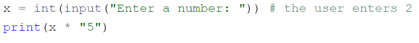

55

1. Який очікуваний результат наступного фрагмента?

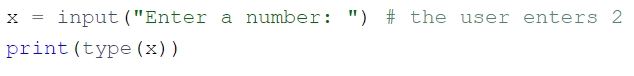

class 'str'

## References

1. Anaconda (Python distribution))
2. [Conda](https://conda.io/en/latest/)
3. [Pro Git Book](https://git-scm.com/book/en/v2)
4. [OpenEDG Python Institute](https://pythoninstitute.org/)
5. [Cisco. Networking Academy](https://www.netacad.com/)
6. [Научно-издательская система Quarto](https://data-visualization-blog.netlify.app/posts/quarto/)